# Characterizing crimes in Los Angeles

Author

Dilrose Karakattil & Harshita Bharadwaj

Published

October 20, 2023

## Research Questions (RQ)

We believe the first research question in our project is nicely written, thus we will leave it alone. We have revised the second, third and the fourth research topics based on feedback from the proposal.

**Research question 2:** What is the specific location in Los Angeles experiencing the highest crime rate, and how might allocating additional police resources to this area enhance crime prevention and promote community well-being?

**Research question 3:** What are the month wise trends in crime counts in Los Angeles for the years 2020, 2021, and 2022, and how do various factors influencing these trends over the three-year period?”

**Research question 4:** What are the top five crimes that occurred between 2020 and 2023, and how many victims were affected by victim sex?

## Data sources

**Data files -** Crime_Data_from_2020_to_Present.csv

**Date downloaded -** September 14, 2023

**Description -** This data set contains crime reports from the city of Los Angeles dating back to 2020. This data is copied from original crime reports that were recorded on paper, therefore there may be some mistakes. Some missing data location fields are denoted as (0°, 0°). To ensure privacy, address fields are only provided to the closest hundred block.

**Source of downloaded file -** It’s taken from the Data.gov website. Data.gov is the United States government’s open data website. It provides access to datasets published by agencies across the federal government. Data.gov is intended to provide access to government open data to the public, achieve agency missions, drive innovation, fuel economic activity, and uphold the ideals of an open and transparent government. https://catalog.data.gov/dataset/crime-data-from-2020-to-present

**Original source -** The original data source is provided by the Los Angeles Police Department on data.lacity.org/ website. https://data.lacity.org/Public-Safety/Crime-Data-from-2020-to-Present/2nrs-mtv8

**Validity of data -** Our data comes from an authentic source, the Los Angeles Police Department. According to the original source, the data collected has been transcribed from original criminal reports that are typed on paper, so there may be some mistakes in the data. We presume the data is biased because it was collected by the LAPD. The different factors involved in skewed data may include the time of day the crime happened, police employment, socioeconomic and racial bias, data entry errors, political and organizational pressure, data collection methods, and so on.

## Evaluating proposal expectations

To demonstrate how the data is distributed, we summarized the idea of centrality for the variable victim_age. It appears that the median age is 37; if the median is 37, we know that half of the individuals in the data set are 37 years old or younger, and half are 37 years old or older.

```r
df <- read_csv(here("data_processed", "clean_crime_data.csv"))

df %>%
    filter(victim_age != 0) %>%
    filter(victim_sex %in% c("M","F")) %>%
    summarise( median = median(victim_age),
               mean = mean(victim_age),
               sd = sd(victim_age))
```

```
#> # A tibble: 1 × 3
#>   median  mean    sd
#>    <dbl> <dbl> <dbl>
#> 1     37  39.8  15.5
```

We have also utilized factoring concept in this. We categorized offenses depending on the number of observations we have, with the remaining crimes falling into the “All Other Crimes” category. We used the boxplot data visualization technique to investigate the key association between data variables such as ‘victim_age’ and ‘grouped_crime’. Box plots provide a visual representation of the median, quartiles, and potential outliers.

**Summary Statistics**: We calculated summary statistics for victim_age within each crime_name category. This will aid in understanding how the ages of victims differ for different sorts of crimes.

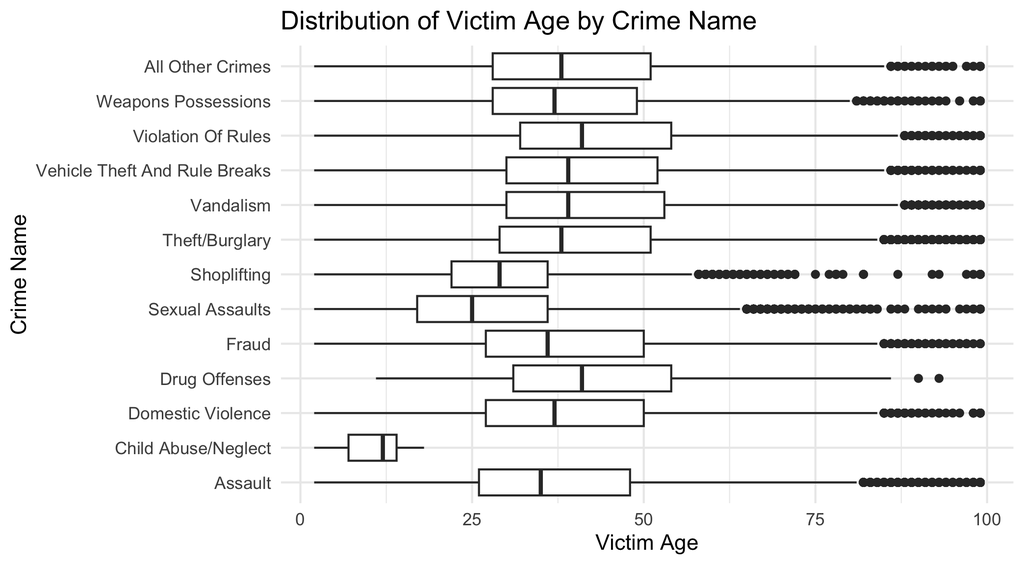

```r
df1 <- df %>%
    filter(victim_age >= 1 & victim_age <= 100) %>%
  mutate(
    grouped_crime = fct_other(grouped_crime, keep = c(
      "Theft/Burglary", "Assault", "Vehicle Theft And Rule Breaks", "Vandalism",
      "Violation Of Rules", "Domestic Violence", "Shoplifting", "Weapons Possessions",
      "Fraud", "Sexual Assaults", "Child Abuse/Neglect", "Drug Offenses")),
    grouped_crime = fct_recode(grouped_crime, "All Other Crimes" = "Other"),
  ) %>%
    filter(!(grouped_crime == "Child Abuse/Neglect" & victim_age > 18))

View(df1)

ggplot(df1, aes(x = victim_age, y = grouped_crime)) +
  geom_boxplot() +
  labs(title = "Distribution of Victim Age by Crime Name", x = "Victim Age", y = "Crime Name") +        theme_minimal()
```

#### Observations

In summary, a right-skewed box plot for victim age and crime name suggests that the majority of victims tend to be younger, while there are relatively fewer cases involving older victims. As a result, we discovered support for the anticipated relationship described in our proposal.

## Preliminary Charts

We did a little more data wrangling with our data. We used the `lubridate` package to extract the day, month, and year from the date column and then constructed new datasets by filtering each year.

```r
df <- read_csv(here("data_processed", "clean_crime_data.csv"), show_col_types = FALSE)
head(df)
```

```
#> # A tibble: 6 × 16
#>    ...1 date_occured  year month day   area  area_name   crime_description
#>   <dbl> <date>       <dbl> <chr> <chr> <chr> <chr>       <chr>
#> 1     1 2020-01-08    2020 Jan   Wed   03    Southwest   Battery - Simple Assau…
#> 2     2 2020-01-01    2020 Jan   Wed   01    Central     Battery - Simple Assau…
#> 3     3 2020-02-13    2020 Feb   Thu   01    Central     Sex Offender Registran…
#> 4     4 2020-01-01    2020 Jan   Wed   15    N Hollywood Vandalism - Misdeamean…
#> 5     5 2020-01-01    2020 Jan   Wed   19    Mission     Vandalism - Felony ($4…
#> 6     6 2020-01-01    2020 Jan   Wed   01    Central     Rape, Forcible
#> # ℹ 8 more variables: victim_age <dbl>, victim_sex <chr>, victim_descent <chr>,
#> #   premis_desc <chr>, weapon_description <chr>, location <chr>,
#> #   cross_street <chr>, grouped_crime <chr>
```

```r
# data frame having count of each crime in each area in the year 2020
df_crime_counts_area_2020 <- df %>%
  filter(year == 2020) %>%
  mutate(
    grouped_crime = fct_other(grouped_crime, keep = c(
      "Theft/Burglary", "Assault", "Vehicle Theft And Rule Breaks", "Vandalism",
      "Violation Of Rules", "Domestic Violence", "Shoplifting", "Weapons Possessions",
      "Fraud", "Sexual Assaults", "Child Abuse/Neglect", "Drug Offenses")),
    grouped_crime = fct_recode(grouped_crime, "All Other Crimes" = "Other")
  ) %>%
  group_by(grouped_crime, area_name) %>%
  count() %>%
  arrange(grouped_crime, desc(n))

# data frame having count of each crime in the year 2020
df_crime_counts_2020 <- df %>%
  filter(year == 2020) %>%
  group_by(grouped_crime) %>%
  count() %>%
  arrange(desc(n))

write.csv(x = df_crime_counts_area_2020, file = "data_processed/count_crime_eachArea2020.csv")
write.csv(x = df_crime_counts_2020, file = "data_processed/count_crime_2020.csv")
```

```r
# data frame having count of each crime in each area in the year 2021
df_crime_counts_area_2021 <- df %>%
  filter(year == 2021) %>%
  mutate(
    grouped_crime = fct_other(grouped_crime, keep = c(
      "Theft/Burglary", "Assault", "Vehicle Theft And Rule Breaks", "Vandalism",
      "Violation Of Rules", "Domestic Violence", "Shoplifting", "Weapons Possessions",
      "Fraud", "Sexual Assaults", "Child Abuse/Neglect", "Drug Offenses")),
    grouped_crime = fct_recode(grouped_crime, "All Other Crimes" = "Other")
  ) %>%
  group_by(grouped_crime, area_name) %>%
  count() %>%
  arrange(grouped_crime, desc(n))

# data frame having count of each crime in the year 2021
df_crime_counts_2021 <- df %>%
  filter(year == 2021) %>%
  group_by(grouped_crime) %>%
  count() %>%
  arrange(desc(n))

write.csv(x = df_crime_counts_area_2021, file = "data_processed/count_crime_eachArea2021.csv")
write.csv(x = df_crime_counts_2021, file = "data_processed/count_crime_2021.csv")
```

```r
# data frame having count of each crime in each area in the year 2022
df_crime_counts_area_2022 <- df %>%
  filter(year == 2022) %>%
  mutate(
    grouped_crime = fct_other(grouped_crime, keep = c(
      "Theft/Burglary", "Assault", "Vehicle Theft And Rule Breaks", "Vandalism",
      "Violation Of Rules", "Domestic Violence", "Shoplifting", "Weapons Possessions",
      "Fraud", "Sexual Assaults", "Child Abuse/Neglect", "Drug Offenses")),
    grouped_crime = fct_recode(grouped_crime, "All Other Crimes" = "Other")
  ) %>%
  group_by(grouped_crime, area_name) %>%
  count() %>%
  arrange(grouped_crime, desc(n))

# data frame having count of each crime in the year 2022
df_crime_counts_2022 <- df %>%
  filter(year == 2022) %>%
  group_by(grouped_crime) %>%
  count() %>%
  arrange(desc(n))

write.csv(x = df_crime_counts_area_2022, file = "data_processed/count_crime_eachArea2022.csv")
write.csv(x = df_crime_counts_2022, file = "data_processed/count_crime_2022.csv")
```

```r
# data frame having count of each crime in each area in the year 2023
df_crime_counts_area_2023 <- df %>%
  filter(year == 2023) %>%
  mutate(
    grouped_crime = fct_other(grouped_crime, keep = c(
      "Theft/Burglary", "Assault", "Vehicle Theft And Rule Breaks", "Vandalism",
      "Violation Of Rules", "Domestic Violence", "Shoplifting", "Weapons Possessions",
      "Fraud", "Sexual Assaults", "Child Abuse/Neglect", "Drug Offenses")),
    grouped_crime = fct_recode(grouped_crime, "All Other Crimes" = "Other")
  ) %>%
  group_by(grouped_crime, area_name) %>%
  count() %>%
  arrange(grouped_crime, desc(n))

# data frame having count of each crime in the year 2023
df_crime_counts_2023 <- df %>%
  filter(year == 2023) %>%
  group_by(grouped_crime) %>%
  count() %>%
  arrange(desc(n))

write.csv(x = df_crime_counts_area_2023, file = "data_processed/count_crime_eachArea2023.csv")
write.csv(x = df_crime_counts_2023, file = "data_processed/count_crime_2023.csv")
```

### Chart 1

**Research question 2:** What is the specific location in Los Angeles experiencing the highest crime rate, and how might allocating additional police resources to this area enhance crime prevention and promote community well-being?

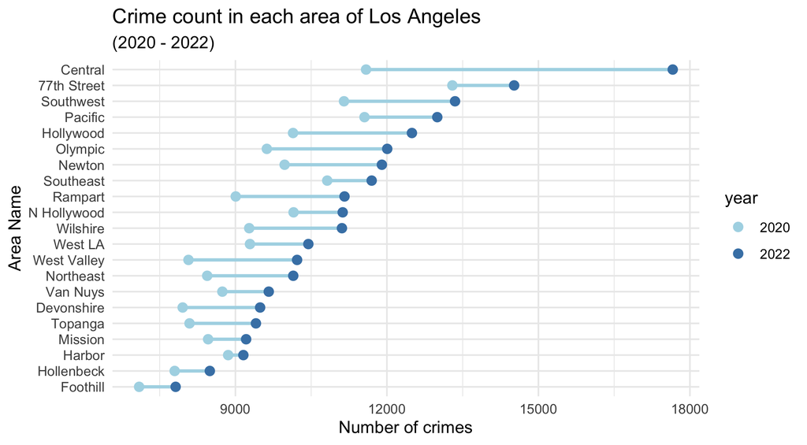

```r
df <- read_csv(here("data_processed", "clean_crime_data.csv"))

df %>%
    filter(year %in% c(2020, 2022)) %>%
    group_by(area_name, year) %>%
    count() %>%
    mutate(
        year = as.factor(year)
    ) %>%
    arrange(year) %>%
    ggplot(aes(x = n, y = fct_reorder2(area_name, year, desc(n)))) +
    geom_line(aes(group = area_name), color = 'lightblue', size = 1) +
    geom_point(aes(color = year), size = 2.5) +
    scale_color_manual(
      values = c('lightblue', 'steelblue')) +
    theme_minimal() +
    labs(
        x = "Number of crimes",
        y = "Area Name",
        title = "Crime count in each area of Los Angeles",
        subtitle = "(2020 - 2022)"
    )
```

```r
# Save the ggplot to a file using ggsave
#ggsave("figs/crime_count_eachArea.png", width = 6, height = 4, dpi = 300)
```

### Chart 2

**Research question 3:** What are the month wise trends in crime counts in Los Angeles for the years 2020, 2021, and 2022, and how do various factors influencing these trends over the three-year period?”

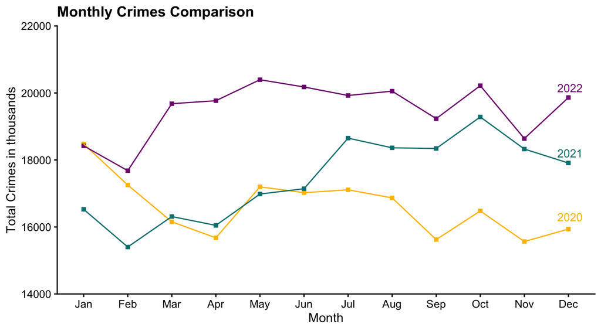

```r
Cl_crime  <- read_csv(here("data_processed", "clean_crime_data.csv"))

# Define the order of months
months_order <- c("Jan", "Feb", "Mar", "Apr", "May", "Jun", "Jul", "Aug", "Sep", "Oct", "Nov", "Dec")

# Filter data for each year and calculate monthly total crimes

crimes_2020 <- Cl_crime[Cl_crime$year == 2020,]
crimes_2020$month <- factor(crimes_2020$month, levels = months_order)
month_wise_2020 <- crimes_2020 %>%
  group_by(month) %>%
  summarise(total_crimes = n()) %>%
  arrange(desc(total_crimes))

crimes_2021 <- Cl_crime[Cl_crime$year == 2021,]
crimes_2021$month <- factor(crimes_2021$month, levels = months_order)
month_wise_2021 <- crimes_2021 %>%
  group_by(month) %>%
  summarise(total_crimes = n()) %>%
  arrange(desc(total_crimes))

crimes_2022 <- Cl_crime[Cl_crime$year == 2022,]
crimes_2022$month <- factor(crimes_2022$month, levels = months_order)
month_wise_2022 <- crimes_2022 %>%
  group_by(month) %>%
  summarise(total_crimes = n()) %>%
  arrange(desc(total_crimes))

# Combine data for all three years
combined_data <- rbind(
  transform(month_wise_2020, year = 2020),
  transform(month_wise_2021, year = 2021),
  transform(month_wise_2022, year = 2022))

# Reorder the months factor
combined_data$month <- factor(combined_data$month, levels = months_order)

#Finding the mean crime counts
#mean_crime_count <- mean(combined_data$total_crimes)
#mean_crimes_2020 <- mean(month_wise_2020$total_crimes)
#mean_crimes_2021 <- mean(month_wise_2021$total_crimes)
#mean_crimes_2022 <- mean(month_wise_2022$total_crimes)

# Create the line graph with different colors for different years and without legend
ggplot(combined_data, aes(x = month, y = total_crimes, group = year, color = as.factor(year))) +
  geom_point(shape = 15, size = 1.5) +
  geom_line() +
#facet_wrap(vars(year), nrow = 1) +
  labs(x = "Month", y = "Total Crimes in thousands") +
  ggtitle("Monthly Crimes Comparison") +
  scale_color_manual(values = c("#FFBF00", "#008080", "#800080")) +
  scale_y_continuous(limits = c(14000, 22000), expand = expansion(mult = c(0, 0))) +
     annotate(geom = "text", x = 11.75, y = 16300, label = "2020",  hjust = 0, vjust = 0.5, size = 3.5, color="#FFBF00")+
  annotate(geom = "text", x = 11.75, y = 18200, label = "2021",  hjust = 0, vjust = 0.5, size = 3.5, color="#008080") +
  annotate(geom = "text", x = 11.75, y = 20150, label = "2022",  hjust = 0, vjust = 0.5, size = 3.5, color="#800080") +
  theme_half_open(font_size = 11) +
  guides(color = FALSE)
```

```r
# Save the ggplot to a file using ggsave
ggsave("figs/monthlyComparison.png", width = 6, height = 4, dpi = 300)
```

#### Key Insights

Drilling down further, the data reveals an intriguing pattern of crime rates declining in September, only to spike upwards in October across all 3 years. September represents a stabilization following the summer peak, as schools reopen providing structure for youth, weather gradually cools while remaining mild, tourism dies down, police ramp up after summer, people return from vacations and seasonal jobs end. This convergence results in a dip in crimes. However, October then faces multiple transitions that disrupt the stabilization. The holiday shopping season also ramps up in October, with year-end inventory stocking up in stores combined with gift purchase pressures. This drives financially desperate individuals towards retail theft and robberies.

In 2021, there was an initial period of relative calm in terms of crime rates when compared to the previous year, 2020. This period of lower crime rates extended for the first half of the year. However, this trend drastically changed in the latter half of 2021. During these six months, crime rates rose significantly, surpassing the average crime rates for the entire year. Notably, October 2021 saw the highest crime rates for the entire year. A specific incident that gained significant attention and likely contributed to the surge in crime rates occurred on October 27, 2021. On this day, a Long Beach Unified School safety officer was charged with murder in the shooting death of an unarmed 18-year-old. This incident led to public outrage, protests, and strikes, possibly adding to the overall tension and contributing to the rise in crime rates for that month. Additionally, it’s suggested in the passage that the increase in crime rates during the latter part of 2021 might have been influenced by the ongoing effects of the COVID-19 lockdowns. As restrictions eased towards the end of July, there could have been a relaxation in social activities, leading to increased interactions and, potentially, more opportunities for criminal activities.

When considering the broader trend, crime counts in 2022 surpassed the mean crime counts of the previous years (2020 and 2021). This upward trend in crime rates over the years was influenced by various factors. Population growth played a role, creating a larger pool of potential offenders and victims. Additionally, the lingering impacts of the pandemic, such as economic disruptions, job losses, and mental health challenges, created an environment conducive to criminal activities. Other significant factors contributing to the rise in crime rates included decriminalization, which reduced the deterrence effect for certain offenses, California decriminalized some property crimes under $950 value. Early release of prisoners to mitigate COVID-19 spread in prisons, potentially leading to an increase in criminal behavior. Economic challenges, reflected in high unemployment rates and increased poverty, created desperation among individuals, driving some towards criminal activities. The surge in homelessness further exacerbated social issues, often linked to petty crimes.

### Chart 3

**Research question 4:** What is the gender distribution of crime victims in Los Angeles, and is there a discernible trend or pattern in terms of which gender is more frequently victimized? Also, what are the top five crimes that occurred between 2020 and 2023, and how many victims were affected by victim sex?

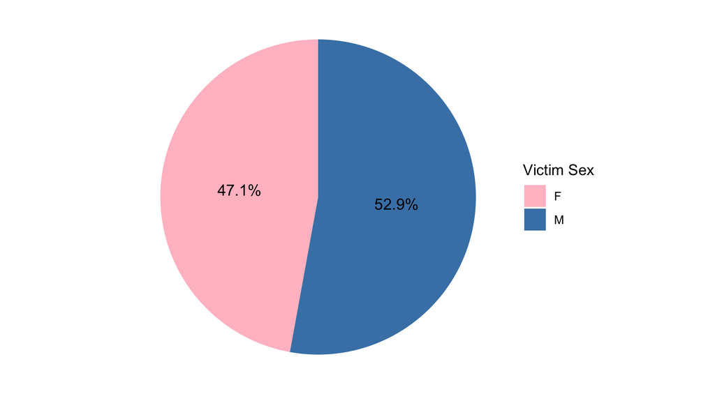

```r
df <- read_csv(here("data_processed", "clean_crime_data.csv"))

# Drop rows with "Unknown" ("X") values in the "victim_sex" column
filtered_crimes <- df %>%
    filter(victim_sex != "X") %>%
    filter(!is.na(victim_sex)) %>%
    filter(victim_sex != "-") %>%
    filter(victim_sex != "H")

# Count the number of victims by sex
victim_counts <- filtered_crimes %>%
  count(victim_sex)

#plot showing which gender is mostly victimized (male OR female?) in a bar graph
custom_colors <- c("M" = "steelblue", "F" = "pink")

# Create a pie chart with values inside each slice
#plot showing which gender is mostly victimized (male OR female?) in a pie chart
ggplot(victim_counts, aes(x = "", y = n, fill = factor(victim_sex))) +
     geom_bar(stat = "identity", width = 1) +
     coord_polar(theta = "y") +
     labs(x = NULL, y = NULL, fill = "Victim Sex") +
     theme_void() +
     theme(legend.position = "right") +
     geom_text(aes(label = scales::percent(n / sum(n), accuracy = 0.1)),
            position = position_stack(vjust = 0.5), size = 4, color = "black") +
     scale_fill_manual(values = custom_colors)
```

```r
# Save the ggplot to a file using ggsave
ggsave("figs/sexDistribution.png", width = 6, height = 4, dpi = 300)
```

```r
options(scipen = 999)
df <- read_csv(here("data_processed", "clean_crime_data.csv"), show_col_types = FALSE)

df1 <- df %>%
    filter(victim_sex %in% c("M","F")) %>%
    mutate(
    grouped_crime = fct_other(grouped_crime, keep = c(
      "Theft/Burglary", "Assault", "Vehicle Theft And Rule Breaks", "Vandalism",
      "Violation Of Rules", "Domestic Violence", "Shoplifting", "Weapons Possessions",
      "Fraud", "Sexual Assaults", "Child Abuse/Neglect", "Drug Offenses")),
    grouped_crime = fct_recode(grouped_crime, "All Other Crimes" = "Other")
    )

# top 5 crimes by victim sex
df1 %>%
  group_by(grouped_crime, victim_sex) %>%
    count() %>%
    group_by(victim_sex) %>%
    mutate(grouped_crime = fct_reorder(grouped_crime, n)) %>%
    arrange(desc(n)) %>%
    slice(1:5) %>%
    head(10)
```

```
#> # A tibble: 10 × 3
#> # Groups:   victim_sex [2]
#>    grouped_crime                 victim_sex      n
#>    <fct>                         <chr>       <int>
#>  1 Theft/Burglary                F          112566
#>  2 Assault                       F           85289
#>  3 Vandalism                     F           25510
#>  4 Violation Of Rules            F           17823
#>  5 Vehicle Theft And Rule Breaks F           14493
#>  6 Theft/Burglary                M          138034
#>  7 Assault                       M           82866
#>  8 Vandalism                     M           31966
#>  9 Vehicle Theft And Rule Breaks M           25118
#> 10 Violation Of Rules            M           10876
```

```r
# count of sum of victim sex for top 5 crimes
df1 %>%
  group_by(grouped_crime, victim_sex) %>%
    count() %>%
    group_by(victim_sex) %>%
    mutate(grouped_crime = fct_reorder(grouped_crime, n)) %>%
    arrange(desc(n)) %>%
    slice(1:5) %>%
    summarise(total = sum(n))
```

```
#> # A tibble: 2 × 2
#>   victim_sex  total
#>   <chr>       <int>
#> 1 F          255681
#> 2 M          288860
```

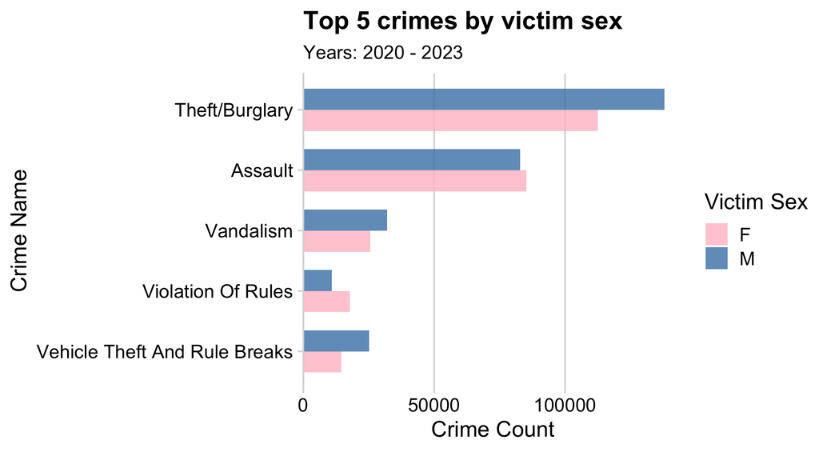

```r
df1 %>%
  group_by(grouped_crime, victim_sex) %>%
    count() %>%
    group_by(victim_sex) %>%
    mutate(grouped_crime = fct_reorder(grouped_crime, n)) %>%
    arrange(desc(n)) %>%
    slice(1:5) %>%

    # Make the chart
    ggplot() +
    geom_col(aes(x = n, y = grouped_crime, fill = victim_sex),
    width = 0.7, alpha = 0.8, position = "dodge") +
    theme_minimal() +
    scale_x_continuous(
    expand = expansion(mult = c(0, 0.05))) +
    scale_fill_manual(values = c('pink', 'steelblue')) +
    theme_minimal_vgrid() +
    labs(
      x = "Crime Count",
      y = "Crime Name",
      fill = "Victim Sex",
      title = "Top 5 crimes by victim sex",
      subtitle = "Years: 2020 - 2023"
    )
```

```r
# Save the ggplot to a file using ggsave
ggsave("figs/top5crimes_byVictimSex.png", width = 6, height = 4, dpi = 300)
```

#### Expectation

Is it true that women are more commonly victimized than men?

#### Conclusion

Males are more likely to be victims of crime, according to the graph above. In the top five offenses, there were 288860 male victims and 255681 female victims. Furthermore, the top five crimes committed between the years 2020 and 2023 are theft/burglary, followed by assault, vandalism, and so on.

## Attribution

“All members contributed equally”.

### Appendix

**Description -** The variables and their description of the data set are as follows:

*DR_NO* - Division of Records Number: Official file number made up of a 2 digit year, area ID, and 5 digits

*Date Rptd* - MM/DD/YYYY - The date of reported crime

*DATE OCC* - MM/DD/YYYY - The date of crime occurred

*TIME OCC* - MM/DD/YYYY - The time of crime occurred

*AREA* - The LAPD has 21 Community Police Stations referred to as Geographic Areas within the department. These Geographic Areas are sequentially numbered from 1-21.

*AREA NAME* - The 21 Geographic Areas or Patrol Divisions are also given a name designation that references a landmark or the surrounding community that it is responsible for.

*Rpt Dist No.* - A four-digit code that represents a sub-area within a Geographic Area.

*Crm Cd* - Indicates the crime committed.

*Crm Cd Desc* - Defines the Crime Code provided.

*Mocodes* - Modus Operandi: Activities associated with the suspect in commission of the crime.

*Vict Age* - Victim Age

*Vict Sex* - F - Female M - Male X - Unknown

*Vict Descent* - Descent Code: A - Other Asian B - Black C - Chinese D - Cambodian F - Filipino G - Guamanian H - Hispanic/Latin/Mexican I - American Indian/Alaskan Native J - Japanese K - Korean L - Laotian O - Other P - Pacific Islander S - Samoan U - Hawaiian V - Vietnamese W - White X - Unknown Z - Asian Indian

*Premis Cd* - The type of structure, vehicle, or location where the crime took place.

*Premis Desc* - Defines the Premise Code provided.

*Weapon Used Cd* - The type of weapon used in the crime.

*Weapon Desc* - Defines the Weapon Used Code provided.

*Status* - Status of the case. (IC is the default)

*Status Desc* - Defines the Status Code provided.

*Crm Cd 1* - Indicates the crime committed. Crime Code 1 is the primary and most serious one. Crime Code 2, 3, and 4 are respectively less serious offenses. Lower crime class numbers are more serious.

*Crm Cd 2* - May contain a code for an additional crime, less serious than Crime Code 1.

*Crm Cd 3* - May contain a code for an additional crime, less serious than Crime Code 1.

*Crm Cd 4* - May contain a code for an additional crime, less serious than Crime Code 1.

*LOCATION* - Street address of crime incident rounded to the nearest hundred block to maintain anonymity. Cross Street - Cross Street of rounded Address

*LAT* - Latitude

*LON* - Longtitude

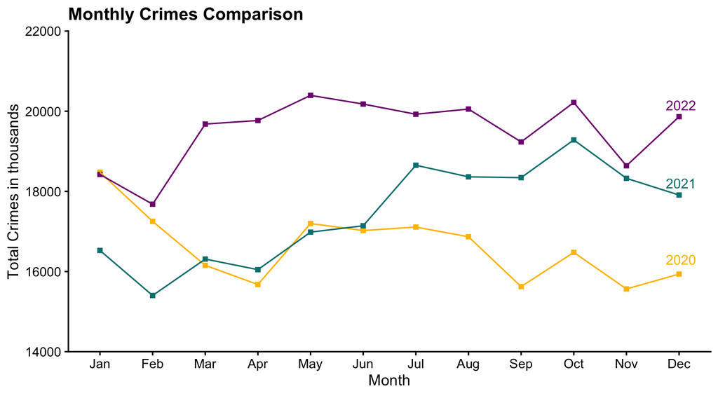

```r
# Create the line graph with different colors for different years and without legend
ggplot(combined_data, aes(x = month, y = total_crimes, group = year, color = as.factor(year))) +
  geom_point(shape = 15, size = 1.5) +
  geom_line() +
#facet_wrap(vars(year), nrow = 1) +
  labs(x = "Month", y = "Total Crimes in thousands") +
  ggtitle("Monthly Crimes Comparison") +
  scale_color_manual(values = c("#FFBF00", "#008080", "#800080")) +
  scale_y_continuous(limits = c(14000, 22000), expand = expansion(mult = c(0, 0))) +
     annotate(geom = "text", x = 11.75, y = 16300, label = "2020",  hjust = 0, vjust = 0.5, size = 3.5, color="#FFBF00")+
  annotate(geom = "text", x = 11.75, y = 18200, label = "2021",  hjust = 0, vjust = 0.5, size = 3.5, color="#008080") +
  annotate(geom = "text", x = 11.75, y = 20150, label = "2022",  hjust = 0, vjust = 0.5, size = 3.5, color="#800080") +
  theme_half_open(font_size = 11) +
  guides(color = FALSE)
```

```r
# Save the ggplot to a file using ggsave
ggsave("figs/monthlyComparison.png", width = 6, height = 4, dpi = 300)
```

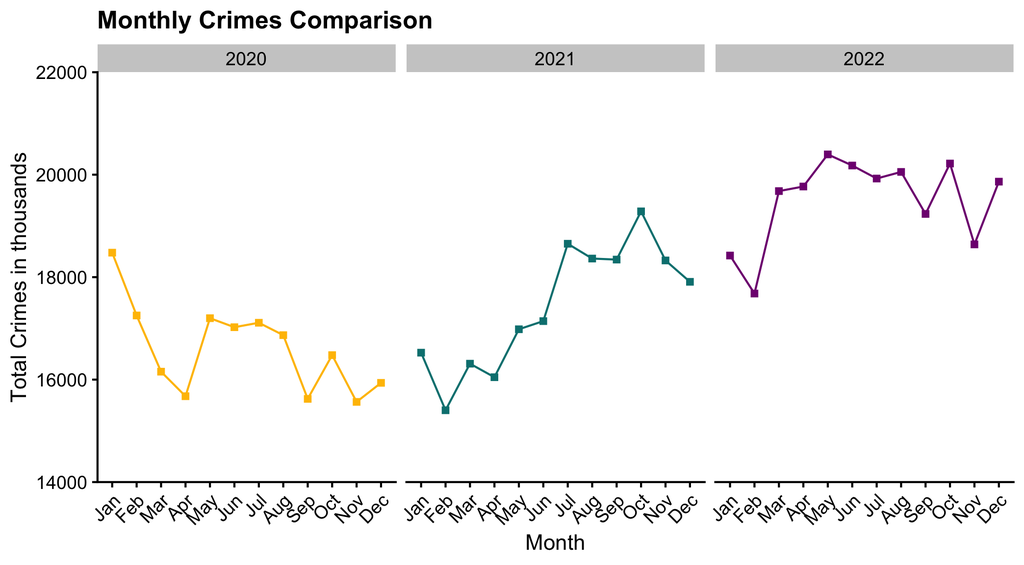

```r
# Create the line graph with different colors for different years and without legend
ggplot(combined_data, aes(x = month, y = total_crimes, group = year, color = as.factor(year))) +
  geom_point(shape = 15, size = 1.5) +
  geom_line() +
  facet_wrap(vars(year), nrow = 1) +
  labs(x = "Month", y = "Total Crimes in thousands") +
  ggtitle("Monthly Crimes Comparison") +
  scale_color_manual(values = c("#FFBF00", "#008080", "#800080")) +
  scale_y_continuous(limits = c(14000, 22000), expand = expansion(mult = c(0, 0))) +
     #annotate(geom = "text", x = 11.75, y = 16300, label = "2020",  hjust = 0, vjust = 0.5, size = 3.5, color="#FFBF00")+
  #annotate(geom = "text", x = 11.75, y = 18200, label = "2021",  hjust = 0, vjust = 0.5, size = 3.5, color="#008080") +
  #annotate(geom = "text", x = 11.75, y = 20150, label = "2022",  hjust = 0, vjust = 0.5, size = 3.5, color="#800080") +
  theme_half_open(font_size = 11) +
  guides(color = FALSE)+
    theme(axis.text.x = element_text(angle = 45, hjust = 1))
```

```r
# Save the ggplot to a file using ggsave
ggsave("figs/monthlyComparison.png", width = 6, height = 4, dpi = 300)
```

```r
crimes_of_interest <- c("Theft/Burglary", "Assault", "Vehicle Theft And Rule Breaks", "Vandalism", "Violation Of Rules")

crime_summary <- df1 %>%

  filter(
    year %in% c(2020, 2022),
    grouped_crime %in% crimes_of_interest) %>%
    group_by(grouped_crime, year) %>%
    count() %>%
    slice(1:5) %>%
  mutate(
    # Reorder state variables
    grouped_crime = fct_reorder2(grouped_crime,
      year, desc(n)),
    # Convert year to discrete variable
    year = as.factor(year),

    # Make labels
    label = paste(grouped_crime, ' (',
                  round(n), ')'),
    label_left = ifelse(year == 2020, label, NA),
    label_right = ifelse(year == 2022, label, NA))


crime_summary %>%
    select(grouped_crime, year, n, label)
```

```
#> # A tibble: 10 × 4
#> # Groups:   grouped_crime, year [10]
#>    grouped_crime                 year      n label
#>    <fct>                         <fct> <int> <chr>
#>  1 Assault                       2020  43799 Assault  ( 43799 )
#>  2 Assault                       2022  47095 Assault  ( 47095 )
#>  3 Theft/Burglary                2020  61577 Theft/Burglary  ( 61577 )
#>  4 Theft/Burglary                2022  78611 Theft/Burglary  ( 78611 )
#>  5 Vandalism                     2020  16223 Vandalism  ( 16223 )
#>  6 Vandalism                     2022  15160 Vandalism  ( 15160 )
#>  7 Vehicle Theft And Rule Breaks 2020   7600 Vehicle Theft And Rule Breaks  ( 7…
#>  8 Vehicle Theft And Rule Breaks 2022  12836 Vehicle Theft And Rule Breaks  ( 1…
#>  9 Violation Of Rules            2020   7390 Violation Of Rules  ( 7390 )
#> 10 Violation Of Rules            2022   7995 Violation Of Rules  ( 7995 )
```

[figure not shown]

```r
ggplot(crime_summary,
       aes(x = year, y = n,
           group = grouped_crime)) +
    geom_line() +
    # Add 1970 labels (left side)
    geom_text_repel(
      aes(label = label_left),
      hjust = 1, nudge_x = -0.05,
      direction = 'y', segment.color = 'grey') +
    # Add 2017 labels (right side)
    geom_text_repel(
      aes(label = label_right),
      hjust = 0, nudge_x = 0.08,
      direction = 'y', segment.color = 'grey') +
    # Move year labels to top, modify line colors
    scale_x_discrete(position = 'top') +
    scale_color_manual(values = c('red', 'black')) +
    scale_y_continuous(
    breaks = c(0, 20000, 40000, 60000),
    expand = expand_scale(mult = c(0, 0.05))) +
    # Annotate & adjust theme
    labs(x = NULL,
         y = 'Milk produced (billion lbs)',
         title = 'Top 10 milk producing states (1970 - 2017)') +
    theme(panel.grid  = element_blank(),
          axis.text.y = element_blank(),
          axis.ticks = element_blank(),
          legend.position = 'none') +
    theme_minimal_grid()
```